# Module 3 Individual Assignment

Bryan Yang

2022-06-21

# Overview

In this assignment, you are going to explore data from the convenience store retail giant NANSE. NANSE owns over seven hundred small-form convenience stores throughout Canada. This dataset only includes sales from 2015 for food and beverage. It also excludes alcohol and tobacco. Each row represents the weekly average for one store for all of 2015. Thus, each row in the data represents the average weekly results for that one store for the whole year. You are going to use EDA to investigate different features of these data.

# ETL (Extract, Transform, Load) Tasks:

```r
library(tidyverse) # load tidyverse.
```

### 1. Import the `store_3HE.csv’ as dataframe df. And learn about the data from the Data_description_store_3HE.xlsx Download Data_description_store_3HE.xlsx to an external site.

```r
df <- read.csv('store_3HE.csv', stringsAsFactors = TRUE) #read csv.
```

### 2. (0.5 points) Familiarize yourself with the features of the data by using the `str()`, `summary()`, `head()`, `tail()`, `slice_sample()`, `unique()`, and `n_distinct()` functions. Give a brief summary of what you learn (just two or three sentences). Note - A few of these functions are from the package “dplyr”. Thus, load “dplyr” or the meta-package “tidyverse” into your RStudio notebook. The package “tidyverse” is used in each R notebook we will work with, so, you will see it often.

```r
str(df) #Look at the data first and understand what we have - 'str()' function.
```

```
## 'data.frame':    771 obs. of  20 variables:
##  $ store                  : int  105 117 122 123 182 183 186 194 227 233 ...
##  $ city                   : Factor w/ 256 levels "ABBOTSFORD","ACHESON",..: 30 33 33 33 60 60 148 148 70 70 ...
##  $ region                 : Factor w/ 4 levels "ATLANTIC","ONTARIO",..: 2 2 2 2 2 2 2 2 2 2 ...
##  $ province               : Factor w/ 10 levels "AB","BC","MB",..: 6 6 6 6 6 6 6 6 6 6 ...
##  $ size                   : int  496 875 691 763 784 NA 966 710 973 967 ...
##  $ revenue                : Factor w/ 770 levels "10036.99","10051.72",..: 768 263 298 308 509 459 738 141 581 619 ...
##  $ units                  : num  470 1131 1229 1258 1950 ...
##  $ cost                   : num  591 1622 1709 1720 2486 ...
##  $ gross_profit           : num  394 1008 1077 1115 1633 ...
##  $ promo_units            : num  210 401 450 477 665 ...
##  $ energy_units           : num  72.1 192.8 240.5 194.2 199.7 ...
##  $ regularBars_units      : num  38.6 75 93.7 99.4 175.5 ...
##  $ gum_units              : num  29.3 55.9 64.3 73.2 145.8 ...
##  $ bagpegCandy_units      : num  13.4 42.1 29.9 54.1 68.1 ...
##  $ isotonics_units        : num  20.7 87.6 105.7 118.2 109.3 ...
##  $ singleServePotato_units: num  18.6 36.4 48 39.7 85.7 ...
##  $ takeHomePotato_units   : num  7.71 33.46 19.9 22.1 42.33 ...
##  $ kingBars_units         : num  17.9 47.4 45.2 45.3 79.8 ...
##  $ flatWater_units        : num  56.5 98.4 130.3 132.8 204.1 ...
##  $ psd591Ml_units         : num  39.7 38.7 47.3 39.9 50.3 ...
```

```r
summary(df) #Look at the data first and understand what we have - 'summary()' function.
```

```
##      store                 city          region       province
##  Min.   :  105   CALGARY     : 35   ATLANTIC: 18   ON     :383
##  1st Qu.: 6226   MISSISSAUGA : 30   ONTARIO :383   QC     :120
##  Median :34438   EDMONTON    : 24   QUEBEC  :131   BC     :107
##  Mean   :34226   LONDON      : 22   WEST    :239   AB     : 93
##  3rd Qu.:59663   MONTRÃƒâ\200°AL: 22                  MB     : 23
##  Max.   :98788   BRAMPTON    : 21                  SK     : 16
##                  (Other)     :617                  (Other): 29
##       size            revenue        units              cost
##  Min.   : 276.0   506.3   :  2   Min.   :  42.65   Min.   :   41.12
##  1st Qu.: 671.8   10036.99:  1   1st Qu.: 911.85   1st Qu.: 1229.12
##  Median : 792.5   10051.72:  1   Median :1351.25   Median : 1843.41
##  Mean   : 755.5   1010.67 :  1   Mean   :1559.78   Mean   : 2180.51
##  3rd Qu.: 893.0   1014.61 :  1   3rd Qu.:1941.60   3rd Qu.: 2689.76
##  Max.   :1163.0   10179.97:  1   Max.   :9715.83   Max.   :14228.89
##  NA's   :15       (Other) :764
##   gross_profit       promo_units      energy_units    regularBars_units
##  Min.   :   36.36   Min.   :  17.5   Min.   :   4.1   Min.   :  5.10
##  1st Qu.:  771.74   1st Qu.: 344.4   1st Qu.: 142.7   1st Qu.: 75.67
##  Median : 1150.93   Median : 499.3   Median : 215.6   Median :110.65
##  Mean   : 1388.03   Mean   : 567.0   Mean   : 253.0   Mean   :123.95
##  3rd Qu.: 1702.92   3rd Qu.: 730.5   3rd Qu.: 317.1   3rd Qu.:154.84
##  Max.   :10457.82   Max.   :3116.5   Max.   :1576.3   Max.   :681.56
##
##    gum_units      bagpegCandy_units isotonics_units  singleServePotato_units
##  Min.   :  1.88   Min.   :  0.00    Min.   :  3.98   Min.   :  1.75
##  1st Qu.: 53.49   1st Qu.: 24.43    1st Qu.: 57.79   1st Qu.: 29.51
##  Median : 77.88   Median : 41.65    Median : 84.48   Median : 44.92
##  Mean   : 85.53   Mean   : 50.33    Mean   : 98.76   Mean   : 56.34
##  3rd Qu.:110.11   3rd Qu.: 63.72    3rd Qu.:124.16   3rd Qu.: 67.84
##  Max.   :318.69   Max.   :381.96    Max.   :562.46   Max.   :439.06
##
##  takeHomePotato_units kingBars_units   flatWater_units   psd591Ml_units
##  Min.   :  0.00       Min.   :  0.00   Min.   :  11.96   Min.   :  0.00
##  1st Qu.: 15.69       1st Qu.: 33.89   1st Qu.:  82.33   1st Qu.: 31.28
##  Median : 28.85       Median : 49.87   Median : 128.98   Median : 48.25
##  Mean   : 38.05       Mean   : 58.68   Mean   : 158.03   Mean   : 60.57
##  3rd Qu.: 49.31       3rd Qu.: 73.33   3rd Qu.: 190.32   3rd Qu.: 74.95
##  Max.   :360.19       Max.   :471.19   Max.   :1424.27   Max.   :390.38
##
```

```r
head(df, n=10) #Look at the data first and understand what we have - 'head()' function.
```

```
##    store       city  region province size revenue   units    cost gross_profit
## 1    105 BROCKVILLE ONTARIO       ON  496   984.7  470.46  590.73       393.97
## 2    117 BURLINGTON ONTARIO       ON  875 2629.32 1131.38 1621.58      1007.74
## 3    122 BURLINGTON ONTARIO       ON  691 2786.73 1229.46 1709.45      1077.27
## 4    123 BURLINGTON ONTARIO       ON  763 2834.49 1257.63 1719.61      1114.88
## 5    182  DON MILLS ONTARIO       ON  784 4118.36 1949.50 2485.83      1632.53
## 6    183  DON MILLS ONTARIO       ON   NA  374.83  186.54  227.36       147.47
## 7    186 NORTH YORK ONTARIO       ON  966 8195.26 3695.46 5069.99      3125.27
## 8    194 NORTH YORK ONTARIO       ON  710 1981.46  954.29 1172.38       809.08
## 9    227  ETOBICOKE ONTARIO       ON  973 4841.67 2185.02 2995.62      1846.06
## 10   233  ETOBICOKE ONTARIO       ON  967 5435.45 2473.71 3315.70      2119.76
##    promo_units energy_units regularBars_units gum_units bagpegCandy_units
## 1       210.23        72.13             38.63     29.29             13.38
## 2       401.46       192.77             75.04     55.85             42.15
## 3       450.04       240.48             93.73     64.27             29.85
```

[output cut: 29 more lines]

```r
tail(df, n=10) #Look at the data first and understand what we have - 'tail()' function.
```

```
##     store        city region province size revenue   units    cost gross_profit
## 762 92583   VANCOUVER   WEST       BC  614 1940.79  875.77 1167.63       773.17
## 763 92586   VANCOUVER   WEST       BC  379  608.04  295.62  361.08       246.96
## 764 92589   PRINCETON   WEST       BC  904 5182.48 2323.46 3180.24      2002.24
## 765 92591     BURNABY   WEST       BC  872 3954.78 1748.50 2426.27      1528.51
## 766 94285     UNKNOWN QUEBEC  UNKNOWN  343 1121.61  534.63  678.85       442.75
## 767 95198       SOOKE   WEST       BC  707 2910.59 1305.92 1777.54      1133.05
## 768 95342 MAPLE RIDGE   WEST       BC  711 1786.36  789.38 1088.62       697.74
## 769 95849   VANCOUVER   WEST       BC  444 1497.23  703.52  902.25       594.97
## 770 97250    WINNIPEG   WEST       MB  723 2093.18  928.54 1325.07       768.11
## 771 98788   VANCOUVER   WEST       BC  885 3753.52 1644.13 2245.66      1507.87
##     promo_units energy_units regularBars_units gum_units bagpegCandy_units
## 762      272.02       105.54             70.56     51.25             23.98
## 763      110.25        33.27             27.42     21.75              0.90
## 764     1088.19       313.00            209.67     75.35             58.54
```

[output cut: 29 more lines]

```r
slice_sample(df, n=10) #Look at the data first and understand what we have - 'slice_sample()' function.
```

```
##    store            city   region province size revenue   units    cost
## 1  65097        BRAMPTON  ONTARIO       ON  770 5159.08 2345.65 3193.21
## 2  65056   NIAGARA FALLS  ONTARIO       ON  775 3337.21 1474.35 2055.49
## 3  91203 NORTH VANCOUVER     WEST       BC  493 1658.69  784.42  981.66
## 4    414          LONDON  ONTARIO       ON  542 1821.12  834.17 1157.46
## 5  13014   SAINT-LAURENT   QUEBEC       QC  352  605.69  313.77  359.92
## 6  85965        EDMONTON     WEST       AB  984 9303.59 3906.62 5810.35
## 7  13053    MONTRÃƒâ\200°AL   QUEBEC       QC  774 3749.76 1671.77 2234.71
## 8  38977         CALGARY     WEST       AB  847 3662.64 1566.00 2240.60
## 9  12642         BEDFORD ATLANTIC       NS  642 1966.47  930.08 1213.33
## 10 37764         CALGARY     WEST       AB  930 5563.95 2460.29 3440.99
##    gross_profit promo_units energy_units regularBars_units gum_units
## 1       1965.87      913.81       485.12            223.96    153.56
## 2       1281.72      580.67       281.08            131.54     78.81
## 3        677.03      240.48        93.83             63.31     53.96
```

[output cut: 29 more lines]

```r
#unique(df) #Look at the data first and understand what we have - 'unique()' function.
```

```r
n_distinct(df) #Look at the data first and understand what we have - 'n_distinct()' function.
```

```
## [1] 771
```

**Seems like there are 20 columns and 771 rows of stores. The structure and summary of the dataframe, the revenue should be numeric data type in order for n_distinct and unique functions to work properly.There are NA’s and Unknowns in the dataframe (City and Province) excluding Revenue.**

### 3. (0.5 points) Convert the values in the `revenue` column to a numeric data type.

```r
df$revenue <- as.numeric(df$revenue) #convert the values in the revnue column to a numeric data type.
str(df$revenue)                     #check structure.
```

```
##  num [1:771] 768 263 298 308 509 459 738 141 581 619 ...
```

```r
summary(df$revenue)                 #check summary.
```

```
##    Min. 1st Qu.  Median    Mean 3rd Qu.    Max.
##     1.0   193.5   386.0   385.8   578.5   770.0
```

### 4. (0.5 points) Delete rows that contain missing values in any of the columns.

```r
df_clean <- df %>% na.omit            #Delete rows that contain missing values in any of the col.
df_clean <- df_clean %>% drop_na()    #Second delete of rows that contain missing values.
```

# EDA (Exploratory Data Analysis) Tasks:

### 5. (1 point) We are interested in understanding what factors influence the revenue for an individual store. From dataframe df, create two dataframes df_low and df_high such that df_low contains data on all the stores with revenue less than the average revenue for the complete data and df_high contains data on all the stores with revenue equal or greater than the average revenue for the complete data. Calculate the average size of the stores in the two dataframes (df_lows and df_high) and comment on the relationship between revenue and size of the stores by discussing the two means (just one or two sentences).

```r
df_lows <- df_clean %>% filter(revenue < mean(revenue, na.rm = TRUE))  #filter rev less than the avg rev.
df_high <- df_clean %>% filter(revenue >= mean(revenue, na.rm = TRUE)) #filter rev more & equal to avg rev.
mean(df_lows$size)                                                    #print avg lows.
```

```
## [1] 713.6395
```

```r
mean(df_high$size)                                                    #print avg high.
```

```
## [1] 797.8245
```

**Based on the calculation of the average size of the stores in the two dataframes (df_lows and df_high), the relationship between revenue and size of the stores is positively correlated because higher revenue stores are bigger than lower revenue stores in average based on the calculated two size means above.**

### 6. (1.5 points) Report and comment on the correlation between revenue and size. First, calculate the correlation between revenue and size in the main dataframe. Next, using the `ggplot()` function, plot the relationship between the revenue and size using an appropriate chart. Finally, discuss in one or two sentences.

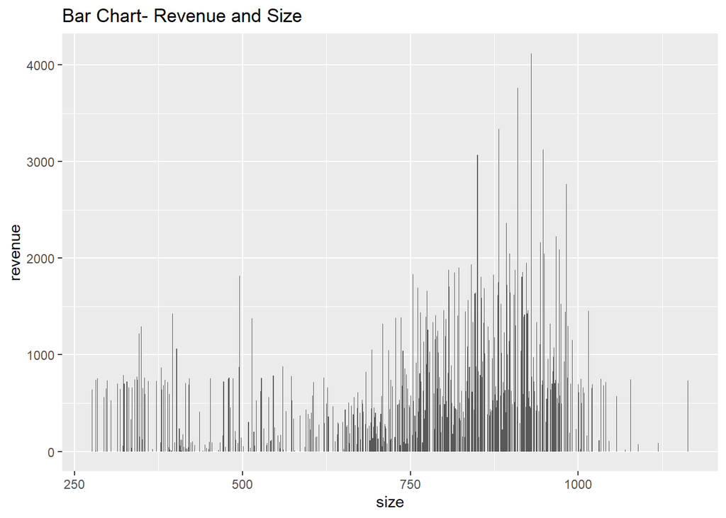

```r
#plot bar chart for size and revenue.
ggplot(df_clean, aes(x=size, y=revenue)) +
  geom_col() +
  labs(title = 'Bar Chart- Revenue and Size')
```

**Overall, the bar plot illustrates negatively skewed bell curve. Based on the chart above, the size has positive effect until approximately 900s reaching above 4000 in revenue. However, there seems to be a trend of diminishing return after the absolute maximum point.**

### 7. (1.5 points) Create boxplots of revenue for each region and comment on the distribution of revenue within each region (in one or two sentences).

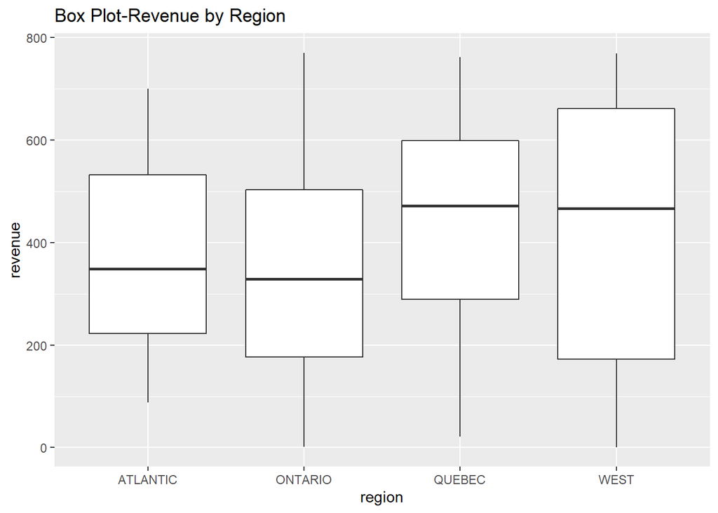

```r
#plot boxplot for revenue and region.
ggplot(df_clean, aes(x=region, y=revenue)) +
  geom_boxplot () +
  labs(title = 'Box Plot-Revenue by Region')
```

### 8. (1.5 points) Calculate the correlation between the revenue and promo_units and comment on whether the value aligns with your expectation. Based on this value of correlation, can you conclude that selling units on promotion helps in increasing revenue? Please explain your reason for the conclusion in a few sentences.

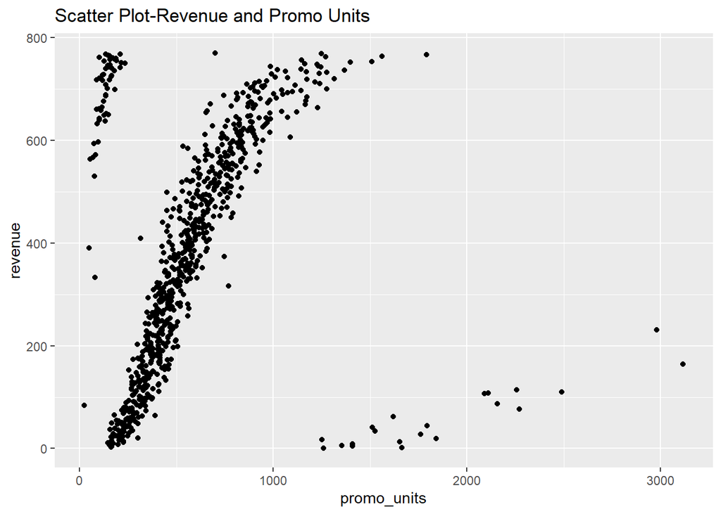

```r
#plot points for promo units and revenue.
ggplot(df_clean, aes(x=promo_units, y=revenue)) +
  geom_point() +
  labs(title = 'Scatter Plot-Revenue and Promo Units')
```

**Based on the scatter plot above, we can observe the positive correlation between revenue and promo units. Therefore, we can conclude that selling units on promotion has an empirical evidence of aiding in increased revenue for stores. However, there are enough outliers that need to be further analyzed for the validity of this correlation.**

### 9. (1.5 points) Create a bar chart that shows total gross_profit for each province. Comment on a few findings from the chart in one or two sentences.

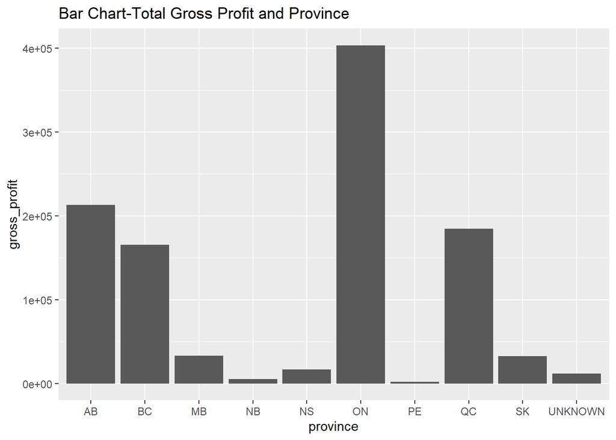

```r
#plot bar chart for total gross proft and province.
ggplot(df_clean, aes(x=province, y=gross_profit)) +
  geom_col() +
  labs(title = 'Bar Chart-Total Gross Profit and Province')
```

### 10. (1.5 points) Create a correlation matrix for showing correlations among the average store sales for all product categories. Which two product categories sell together the least and which sell together the most?

```r
#create separate dataframe for matrix including revenue or sales and all product categories.
df_matrix <- df_clean %>% select(-store, -city, -region, -province, -size, -units, -cost, -gross_profit)
#create matrix for correlation
df_cor <- cor(df_matrix)
min(df_cor)
```

```
## [1] 0.2193379
```

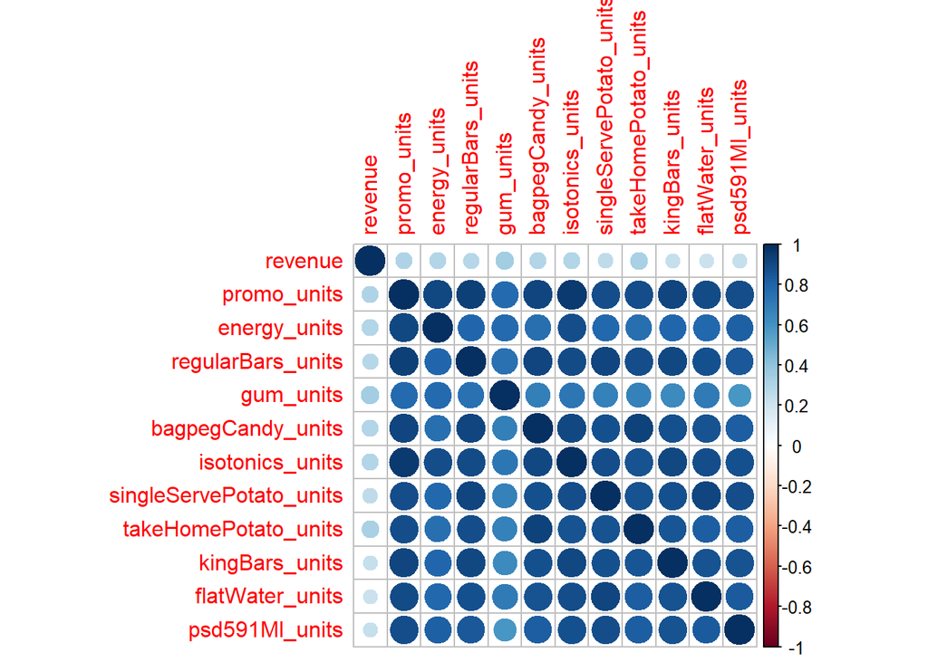

```r
#install package corrplot
#install.packages("corrplot")
corrplot::corrplot(df_cor)
```

**Based on the df_cor matrix and correlation plot above, PSD591MI and Gum units sell together the least (0.58) and Promo and Isotonics units sell together the most (0.95).**